# Wine Project - Part B

Aishwarya Jawalkar

2023-09-20

```r
#Importing the necessary libraries
library(tidyverse)
library(here)
```

*Importing Dataset*

```r
#Reading the data set
file_path_red <- here("Data", "winequality-red.csv")
red_wine_data <- read.table(file_path_red, sep = ";", header = TRUE, stringsAsFactors = FALSE)
view(red_wine_data)
attach(red_wine_data)
```

**Suppose the population mean of the variable “density” is μ , do the following inferences**

**Question 1a. Provide an estimate of μ based on the sample**

```r
mean_density <- mean(density)
mean_density
```

```
## [1] 0.9967467
```

Estimate of μ based on the sample is 0.9967467

**Question 1b. Use the Central Limit Theorem (CLT) to quantify the variability of your estimate**

```r
mu_hat_density <- sd(density)/sqrt(length(density))
mu_hat_density
```

```
## [1] 4.71981e-05
```

Using the CLT, the variability of the estimate is 4.71981e-05.

**Question 1c. Use the CLT to give a 95% confidence interval for μ.**

```r
clt_interval <- c(mean_density - 2*mu_hat_density,mean_density + 2*mu_hat_density)
clt_interval
```

```
## [1] 0.9966523 0.9968411
```

So, using the CLT, the confidence interval for mean μ is between 0.9966523 and 0.9968411

**Question 1d. Use the bootstrap method to do parts b and c, and compare the results with those obtained from the CLT. State your findings.**

```r
mu.hat.set <- NULL
for(k in 1:2000){
  sample.bootstrap <- sample(density, size = 1599, replace = T)
  mu.hat <- mean(sample.bootstrap)
  mu.hat.set[k] <- mu.hat
}

sd(mu.hat.set)
```

```
## [1] 4.676796e-05
```

**Finding the 95% confidence interval using bootstrap method :**

```r
bt_interval <- quantile(mu.hat.set, probs=c(0.025,0.975))
bt_interval
```

```
##      2.5%     97.5%
## 0.9966593 0.9968401
```

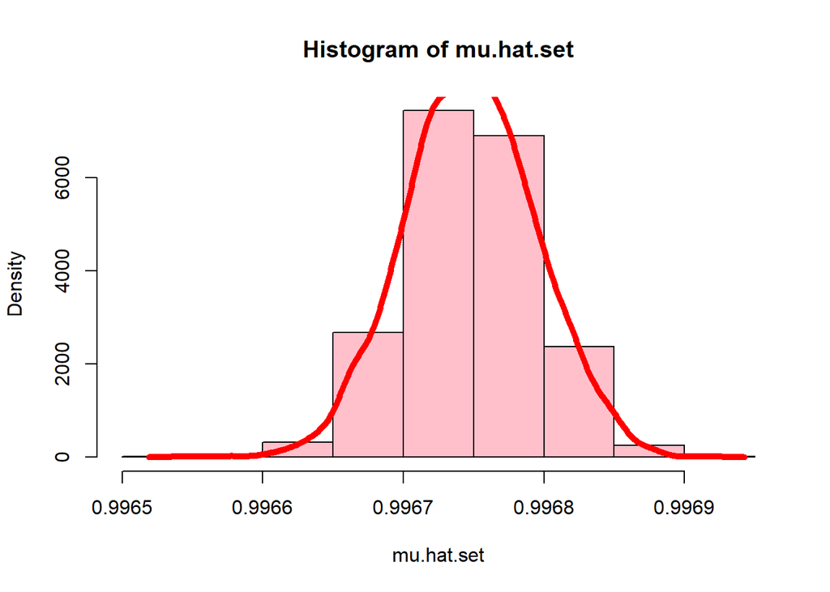

```r
hist(mu.hat.set, freq = FALSE, col = "pink")
lines(density(mu.hat.set), lwd = 5, col = "red")
```

The 95% confidence interval using the CLT method is 0.9966523, 0.9968411 and using the Bootstrap method is 0.9966593, 0.9968401. Looking at both the intervals, we can say that they are quite similar to each other with a very minor difference.

**Suppose the population mean of the variable “residual sugar” is μ , answer the following questions.**

**Question 2a. Provide an estimate of μ based on the sample**

```r
mean_residual_sugar <- mean(residual.sugar)
mean_residual_sugar
```

```
## [1] 2.538806
```

Estimate of μ based on the sample is 2.538806

**Question 2b. Noting that the sample distribution of “residual sugar” is highly skewed, can we use the CLT to quantify the variability of your estimate? Can we use the CLT to give a 95% confidence interval for μ? If yes, please give your solution. If no, explain why.**

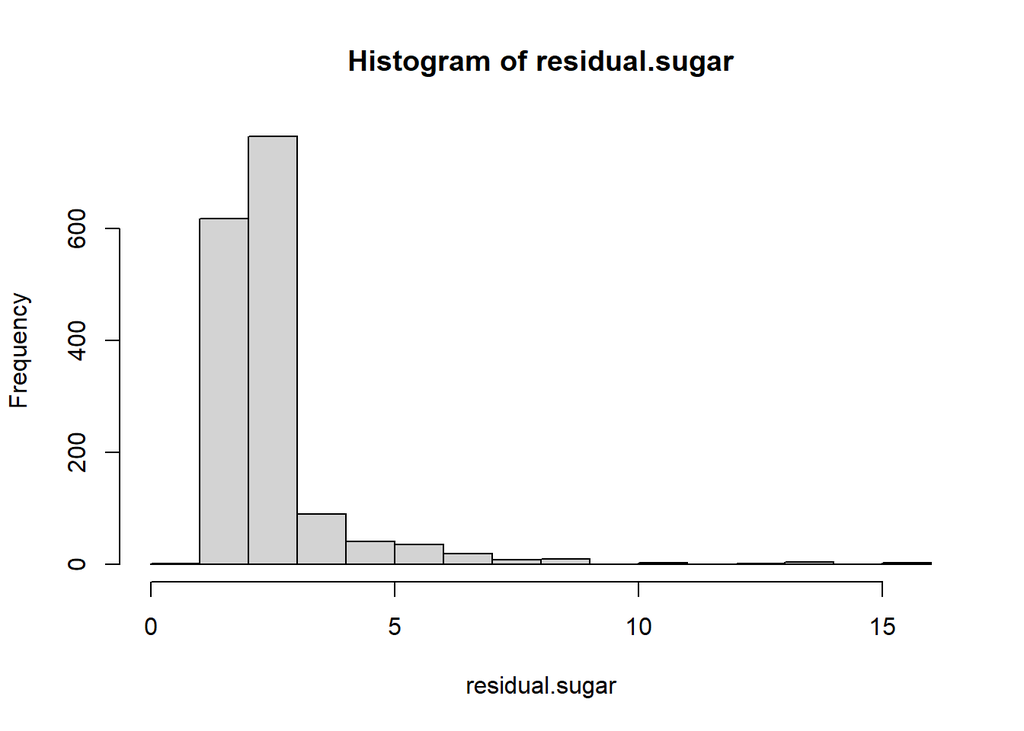

```r
hist(residual.sugar)
```

Yes, we can use the CLT to quantify the variability of the estimate and also we can use CLT to give a 95% confidence interval for μ. Regardless of the type or skewness of the data, which is visible in the histogram, the sample mean approximately follows the same distribution, which is normal.

```r
mu_hat_residual_sugar <- sd(residual.sugar)/sqrt(length(residual.sugar))
mu_hat_residual_sugar
```

```
## [1] 0.03525922
```

The variability of the estimate using CLT is 0.0352592

```r
c(mean_residual_sugar - 2*mu_hat_residual_sugar,mean_residual_sugar + 2*mu_hat_residual_sugar)
```

```
## [1] 2.468287 2.609324
```

So, using the CLT, the confidence interval for mean μ is between 2.468287 and 2.609324

**Question 2c. Use the bootstrap method to do part b. Is the bootstrap confidence interval symmetric?**

```r
mu.hat.set <- NULL
for(k in 1:2000){
  sample.bootstrap <- sample(residual.sugar, size = 1599, replace = T)
  mu.hat <- mean(sample.bootstrap)
  mu.hat.set[k] <- mu.hat
}

sd(mu.hat.set)
```

```
## [1] 0.03512255
```

The 95% confidence interval using bootstrap method:

```r
quantile(mu.hat.set, probs=c(0.025,0.975))
```

```
##     2.5%    97.5%
## 2.469449 2.608852
```

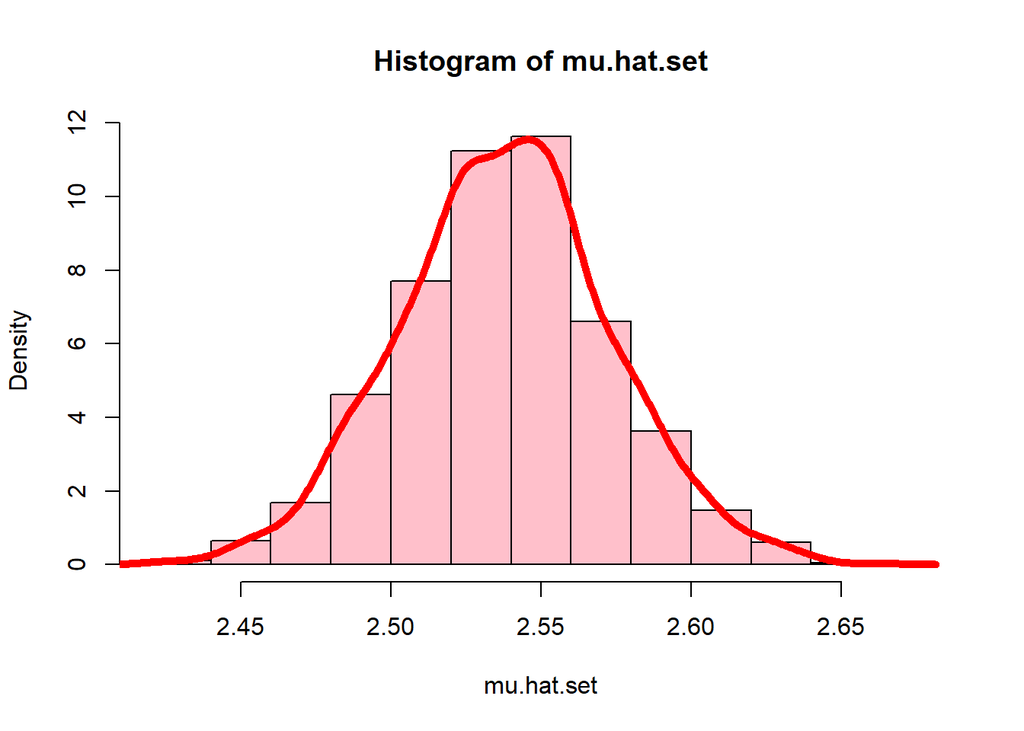

```r
hist(mu.hat.set, freq = FALSE, col = "pink")
lines(density(mu.hat.set), lwd = 5, col = "red")
```

Looking at the histogram we can infer that the bootstrap confidence interval is symmetric.

**Question 3. We classify those wines as “excellent” if their rating is at least 7.**

```r
excellent_wine <- red_wine_data %>%
  mutate(excellent = as.numeric(quality >=7))

attach(excellent_wine)
head(excellent)
```

```
## [1] 0 0 0 0 0 0
```

Let’s consider the population of excellent is ‘p’

**Question 3a. Use the CLT to derive a 95% confidence interval for p**

```r
mean_excellent = mean(excellent)
mean_excellent
```

```
## [1] 0.1357098
```

```r
mu_hat_excellent = sd(excellent)/sqrt(length(excellent))
mu_hat_excellent
```

```
## [1] 0.00856736
```

```r
ctl_confidence <- c(mean_excellent - 2*mu_hat_excellent, mean_excellent + 2*mu_hat_excellent)
ctl_confidence
```

```
## [1] 0.1185751 0.1528445
```

The 95% confidence interval using the CLT is 0.1185751, 0.1528445 So, we can say that the excellent quality wine lies between 11.85% and 15.28%

**Question 3b. Use the bootstrap method to derive a 95% confidence interval for p**

```r
mu.hat.set <- NULL
for(k in 1:2000){
  sample.bootstrap <- sample(excellent, size = 1599, replace = T)
  mu.hat <- mean(sample.bootstrap)
  mu.hat.set[k] <- mu.hat
}

sd(mu.hat.set)
```

```
## [1] 0.008491743
```

```r
boot_interval <- quantile(mu.hat.set, probs=c(0.025,0.975))
boot_interval
```

```
##      2.5%     97.5%
## 0.1194497 0.1519700
```

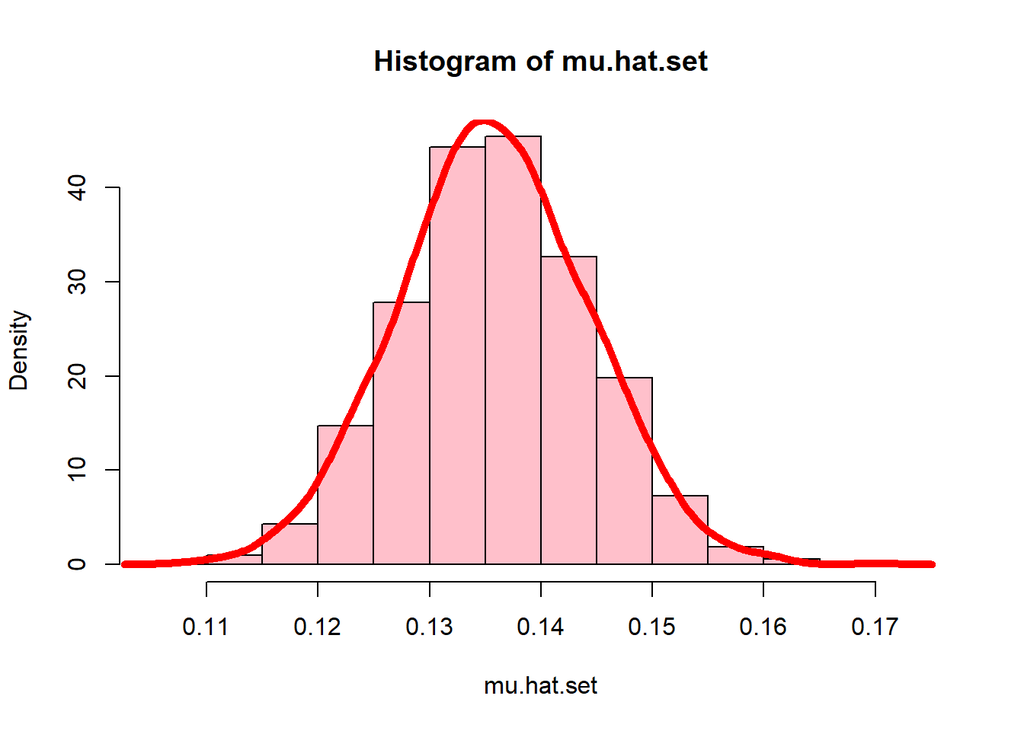

```r
hist(mu.hat.set, freq = FALSE, col = "pink")
lines(density(mu.hat.set), lwd = 5, col = "red")
```